# Monte Carlo Simulation for Structural Estimation

## Big Picture

- First, set the goal of the Monte Carlo simulation.
- The procedure depends on the goal, but many applications follow a similar workflow.
1. Choose the DGP and experimental design.
2. Solve the model.
3. Analyze identification in the population.
4. Generate data and check descriptive statistics.
5. Estimate the model.
6. Conduct inference.
7. Run a counterfactual analysis.
- This note discusses strategies for each step.

## Running Example: A Two-Firm Entry Model Based on Ciliberto and Tamer (2009)

- This note uses a two-firm teaching model based on the logic in Ciliberto and Tamer (2009).
- It is not a replication of their airline application.
- The example retains the central problem:
  - firms may play multiple equilibria;
  - the econometrician does not observe the equilibrium-selection rule;
  - probability bounds identify a set of structural parameters.

### Motivation

- A standard likelihood assigns one probability to each observed market structure.
- A game with multiple equilibria does not deliver that probability without a selection rule.
- Rather than impose an arbitrary rule, we use restrictions that every admissible rule must satisfy.

### Model

- **Players and actions**
  - Two firms are potential entrants in market $m$.
  - $Y_{im}=1$ denotes entry; $Y_{im}=0$ denotes staying out.
- **Information**
  - $X_m\in\{0,1\}$ is an observed market characteristic shared by both firms.
  - $\varepsilon_{im}$ is observed by both firms but not by the econometrician.
  - The game is static and complete information.
- **Parameters**
  - $\beta_i$ measures firm $i$’s response to $X_m$.
  - $\delta_j>0$ measures the competitive pressure exerted by firm $j$.
  - The parameter vector is $\theta=(\beta_1,\beta_2,\delta_1,\delta_2)$.
- **Profit**
  - Staying out gives zero.
  - The payoff from entry is

$$\pi_{im}
=Y_{im}\left[X_m\beta_i-\delta_jY_{jm}+\varepsilon_{im}\right],
\qquad j\neq i.$$

- **Normalization**
  - Stand-alone deterministic profit equals zero when $X_m=0$.
  - The variance of each $\varepsilon_{im}$ is normalized to one.
  - A larger $\delta_j$ makes firm $j$ a stronger competitor.

### Multiple Equilibria

- Firm $i$ enters when

$$Y_{im}
=1\left[X_m\beta_i-\delta_jY_{jm}+\varepsilon_{im}\geq0\right].$$

- Both $(1,0)$ and $(0,1)$ are Nash equilibria when

$$-\beta_1X_m\leq\varepsilon_{1m}\leq\delta_2-\beta_1X_m,$$

$$-\beta_2X_m\leq\varepsilon_{2m}\leq\delta_1-\beta_2X_m.$$

- The blue rectangle in the next figure is the multiplicity region.
- The diagram rewrites Figure 1 of Ciliberto and Tamer (2009) using $-\delta_jY_j$ with $\delta_j>0$.

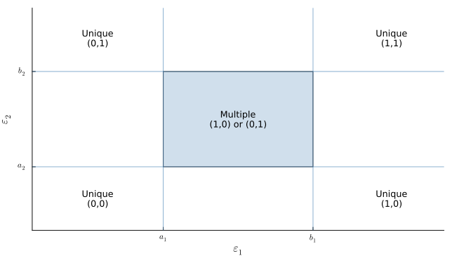

Figure 1: Equilibrium regions for $X=1$ at the true parameter vector.

### Identification

- For outcome $y$ and covariates $X$, define

$$L_y(X;\theta)
=\Pr_\theta(y\text{ is the unique equilibrium}\mid X),$$

$$U_y(X;\theta)
=\Pr_\theta(y\text{ is an equilibrium}\mid X).$$

- Every equilibrium-selection rule satisfies

$$L_y(X;\theta)
\leq \Pr(Y=y\mid X)
\leq U_y(X;\theta).$$

- The identified set contains every parameter vector that satisfies all bounds:

$$\Theta_I
=
\left\{
\theta\in\Theta:
L_y(X;\theta)
\leq\Pr(Y=y\mid X)
\leq U_y(X;\theta)
\text{ for every }y\text{ and almost every }X
\right\}.$$

### Estimation

- Estimate $p_y(x)=\Pr(Y=y\mid X=x)$ within each $X$ cell.
- Penalize violations of the model probability bounds:

$$q_{n,x}(\theta)
=
\sum_y
\left\{
[L_y(x;\theta)-\widehat p_y(x)]_+^2
+[\widehat p_y(x)-U_y(x;\theta)]_+^2
\right\}.$$

- Average only after computing the loss in each cell:

$$Q_n(\theta)
=
\sum_x\widehat{\Pr}(X=x)q_{n,x}(\theta).$$

- The teaching implementation uses the set estimator

$$\widehat\Theta_I
=
\left\{
\theta\in\Theta:nQ_n(\theta)\leq\log\log n
\right\}.$$

- This squared-violation criterion implements the paper’s bound logic in a small discrete-$X$ setting.

## 1. Choose the DGP and experimental design

- Define the DGP and its true parameter values.
- Define alternative experimental designs if needed.

### Remarks

- **DGP**
  - Start with the simplest setting.
    - Use a familiar distribution, such as a normal or uniform distribution.
    - The magnitude of each term can strongly affect identification, so normalize it when appropriate.
  - Even if your research suggests a specific DGP, begin with a simple version.
    - Make the DGP more complicated only after validating the simple version.
- **Experimental design**
  - Include alternative DGPs when the experiment requires a comparison.
  - Examples include:
    - a correctly specified exogenous benchmark;
    - a misspecified model;
    - an endogenous setting estimated without an instrument;
    - endogenous settings estimated with weak and strong instruments.

### Example: The Two-Firm Entry Model

- The observed market state is equally likely to be low or high:

$$\Pr(X_m=0)=\Pr(X_m=1)=0.5.$$

- Shocks are independent across firms and markets:

$$\varepsilon_{im}\sim N(0,1).$$

- The true parameter vector is

$$\theta_0=(0.8,0.6,1.2,0.8).$$

- The finite sample contains $n=5{,}000$ independent markets.
- Uniform equilibrium selection is used only inside the DGP.
- The estimator never observes that selection rule.

```julia
import Pkg

project_root = normpath(joinpath(@__DIR__, "..", ".."))
Pkg.activate(project_root; io = devnull)

ENV["GKSwstype"] = "100"

using DataFrames
using Distributions
using Plots
using Random
using Statistics

VERSION == v"1.12.6" || error("This lesson requires Julia 1.12.6.")

settings = (
    true_theta = (
        beta1 = 0.8,
        beta2 = 0.6,
        delta1 = 1.2,
        delta2 = 0.8,
    ),
    population_grid_points = 19,
    population_grid_tolerance = 1e-8,
    sample_markets = 5_000,
    replications = 100,
    beta1_grid = collect(range(0.00, 1.60; length = 19)),
    beta2_grid = collect(range(0.00, 1.20; length = 19)),
    delta1_grid = collect(range(0.00, 2.40; length = 19)),
    delta2_grid = collect(range(0.00, 1.60; length = 19)),
    confidence_level = 0.95,
    subsample_markets = 910,
    subsamples = 99,
    inference_iterations = 2,
    firm2_entry_subsidy = 0.15,
    example_data_seed = 2_026_081_002,
    example_subsample_seed = 2_026_081_003,
    monte_carlo_data_seed = 2_026_082_000,
    monte_carlo_subsample_seed = 2_026_083_000,
)

profiles = [
    0 1 0 1
    0 0 1 1
]
X_cells = [0, 1]

candidate_rows = [
    (beta1 = beta1, beta2 = beta2, delta1 = delta1, delta2 = delta2)
    for beta1 in settings.beta1_grid
    for beta2 in settings.beta2_grid
    for delta1 in settings.delta1_grid
    for delta2 in settings.delta2_grid
    if delta1 >= delta2
]
candidates = DataFrame(candidate_rows)
@assert nrow(candidates) == 87_001

DataFrame(
    outcome = ["(0,0)", "(1,0)", "(0,1)", "(1,1)"],
    Y1 = profiles[1, :],
    Y2 = profiles[2, :],
)
```

4×3 DataFrame

| Row | outcome String | Y1 Int64 | Y2 Int64 |
| --- | --- | --- | --- |
| 1 | (0,0) | 0 | 0 |
| 2 | (1,0) | 1 | 0 |
| 3 | (0,1) | 0 | 1 |
| 4 | (1,1) | 1 | 1 |

- The ordering $\delta_1\geq\delta_2$ labels firm 1 as the stronger competitor.
- This section defines the experiment; it does not generate outcomes.

## 2. Solve the model

- Write a Julia function that solves the model at a candidate parameter vector.

### Remarks

- The solution method depends on the model, but standard computational techniques often apply.
- Make the solver reusable for counterfactual analysis.
- Validate the code by checking whether the solution satisfies the equilibrium conditions.
- In a game, decide whether the application requires one equilibrium or every equilibrium.
  - Enumerate all action profiles in a small discrete game.
  - Larger models may require multiple starting values, continuation methods, or specialized algorithms.

### Example: The Two-Firm Entry Model

- The model has four possible action profiles.
- We check the best-response conditions for all four profiles.
- The solver returns every pure-strategy Nash equilibrium.

```julia
function equilibrium_mask!(
    mask;
    X,
    epsilon,
    beta1,
    beta2,
    delta1,
    delta2,
)
    standalone_threshold_1 = -X * beta1
    standalone_threshold_2 = -X * beta2

    mask[1] =
        epsilon[1] <= standalone_threshold_1 &&
        epsilon[2] <= standalone_threshold_2
    mask[2] =
        epsilon[1] >= standalone_threshold_1 &&
        epsilon[2] <= standalone_threshold_2 + delta1
    mask[3] =
        epsilon[1] <= standalone_threshold_1 + delta2 &&
        epsilon[2] >= standalone_threshold_2
    mask[4] =
        epsilon[1] >= standalone_threshold_1 + delta2 &&
        epsilon[2] >= standalone_threshold_2 + delta1
    return mask
end

function pure_nash_equilibria(;
    X,
    epsilon,
    beta1,
    beta2,
    delta1,
    delta2,
)
    mask = falses(4)
    equilibrium_mask!(
        mask;
        X = X,
        epsilon = epsilon,
        beta1 = beta1,
        beta2 = beta2,
        delta1 = delta1,
        delta2 = delta2,
    )
    return findall(mask)
end

pure_nash_equilibria(;
    X = 1,
    epsilon = [-0.4, 0.2],
    settings.true_theta...,
)
```

```
2-element Vector{Int64}:
 2
 3
```

- The check returns both asymmetric equilibria for this shock realization.
- Population identification below does not condition on this particular realization.

## 3. Analyze identification in the population

- Derive the population identification conditions analytically.
- Write a Julia function that returns the loss from the identification conditions at a candidate parameter vector.

### Remarks

- This step is not feasible in every setting, but it is important whenever possible.
- Identification in structural models can be ambiguous—even in published work.
  - If the parameters are not identified, estimation cannot recover a unique parameter vector.
  - Population analysis separates an identification problem from finite-sample bias.
- The appropriate approach depends on the model, but a grid search is often the simplest starting point.
  - Evaluate the objective around the true parameter vector.
  - Distinguish point identification from set identification.
  - If the model is set identified, plot low-dimensional projections of the identified set.
  - A coarse grid can miss a lower-dimensional set between grid points.

### Example: The Two-Firm Entry Model

$$a_1(x)=-\beta_1x,
\qquad
a_2(x)=-\beta_2x,$$

$$b_1(x;\theta)=a_1(x)+\delta_2,
\qquad
b_2(x;\theta)=a_2(x)+\delta_1.$$

- The multiplicity probability in cell $x$ is

$$M(x;\theta)
=
[\Phi(b_1)-\Phi(a_1)]
[\Phi(b_2)-\Phi(a_2)].$$

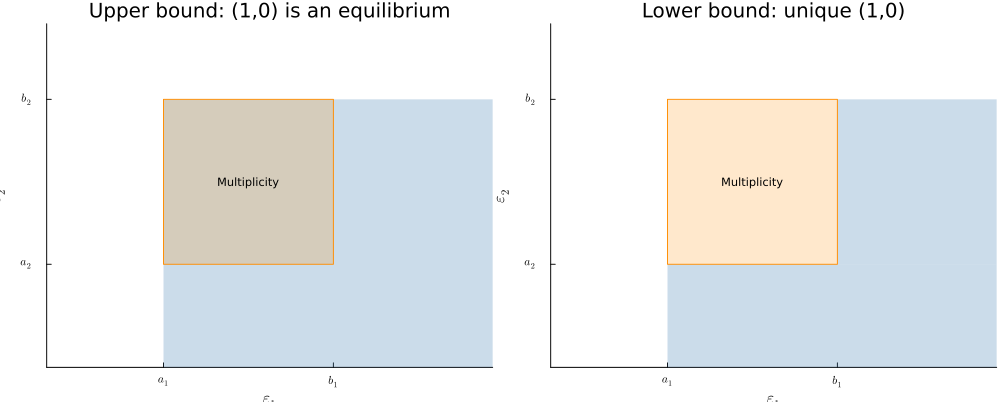

Figure 2: Shock regions defining the upper and lower probability bounds for outcome $(1,0)$.

- **Bounds as shock-space probabilities**
  - The upper bound includes every shock for which $(1,0)$ is an equilibrium.
  - The lower bound excludes the multiplicity rectangle and retains shocks for which $(1,0)$ is unique.
  - The analytical bounds are

$$L_{00}(x;\theta)=U_{00}(x;\theta)
=\Phi(a_1)\Phi(a_2),$$

$$U_{10}(x;\theta)=[1-\Phi(a_1)]\Phi(b_2),
\qquad
L_{10}(x;\theta)=U_{10}(x;\theta)-M(x;\theta),$$

$$U_{01}(x;\theta)=\Phi(b_1)[1-\Phi(a_2)],
\qquad
L_{01}(x;\theta)=U_{01}(x;\theta)-M(x;\theta),$$

$$L_{11}(x;\theta)=U_{11}(x;\theta)
=[1-\Phi(b_1)][1-\Phi(b_2)].$$

- Let $p_y^0(x)$ denote the population outcome probability generated at $\theta_0$.
- Compute a loss separately in each $X$ cell:

$$q_x^{\mathrm{pop}}(\theta)
=
\sum_y
\left\{
[L_y(x;\theta)-p_y^0(x)]_+^2
+[p_y^0(x)-U_y(x;\theta)]_+^2
\right\}.$$

- Average only after computing the cell losses:

$$Q^{\mathrm{pop}}(\theta)
=
\sum_{x\in\{0,1\}}\Pr(X=x)q_x^{\mathrm{pop}}(\theta).$$

- Because both cells have positive probability,

$$Q^{\mathrm{pop}}(\theta)=0
\iff
L_y(x;\theta)\leq p_y^0(x)\leq U_y(x;\theta)
\quad\text{for every }x\text{ and }y.$$

- Therefore, the population identified set is

$$\Theta_I
=
\left\{
\theta\in\Theta:
Q^{\mathrm{pop}}(\theta)=0
\right\}.$$

- Approximate this set on the Cartesian grid

$$G
=
G_{\beta_1}\times G_{\beta_2}\times
G_{\delta_1}\times G_{\delta_2}
\cap\{\delta_1\geq\delta_2\}.$$

- Each parameter grid contains 19 points from 0 to 200 percent of its true value.
- The unrestricted Cartesian product contains $19^4=130{,}321$ points.
- The ordering $\delta_1\geq\delta_2$ leaves 87,001 candidates.
- The exact grid approximation is

$$\Theta_{I,G}
=
\left\{
\theta\in G:
Q^{\mathrm{pop}}(\theta)=0
\right\}.$$

```julia
function analytic_equilibrium_bounds(;
    X_cells,
    beta1,
    beta2,
    delta1,
    delta2,
    firm2_entry_subsidy = 0.0,
)
    cells = length(X_cells)
    lower = zeros(cells, 4)
    upper = zeros(cells, 4)
    multiplicity = zeros(cells)
    standard_normal = Normal()

    for (cell, x) in enumerate(X_cells)
        F1_0 = cdf(standard_normal, -x * beta1)
        F2_0 = cdf(
            standard_normal,
            -x * beta2 - firm2_entry_subsidy,
        )
        F1_delta = cdf(standard_normal, delta2 - x * beta1)
        F2_delta = cdf(
            standard_normal,
            delta1 - x * beta2 - firm2_entry_subsidy,
        )
        multiplicity[cell] =
            (F1_delta - F1_0) * (F2_delta - F2_0)

        lower[cell, 1] = F1_0 * F2_0
        upper[cell, 1] = lower[cell, 1]
        upper[cell, 2] = (1 - F1_0) * F2_delta
        lower[cell, 2] = upper[cell, 2] - multiplicity[cell]
        upper[cell, 3] = F1_delta * (1 - F2_0)
        lower[cell, 3] = upper[cell, 3] - multiplicity[cell]
        lower[cell, 4] = (1 - F1_delta) * (1 - F2_delta)
        upper[cell, 4] = lower[cell, 4]
    end

    return (
        lower = lower,
        upper = upper,
        multiplicity_rate = mean(multiplicity),
    )
end

function uniform_selection_probabilities(; bounds)
    probabilities = copy(bounds.lower)
    probabilities[:, 2] .+=
        0.5 .* (bounds.upper[:, 2] .- bounds.lower[:, 2])
    probabilities[:, 3] .+=
        0.5 .* (bounds.upper[:, 3] .- bounds.lower[:, 3])
    return probabilities
end

function conditional_bound_violation_objective(;
    observed_probabilities,
    cell_weights,
    bounds,
)
    objective = 0.0
    for cell in axes(observed_probabilities, 1)
        cell_loss = 0.0
        for outcome in axes(observed_probabilities, 2)
            observed = observed_probabilities[cell, outcome]
            lower_violation = max(
                bounds.lower[cell, outcome] - observed,
                0.0,
            )
            upper_violation = max(
                observed - bounds.upper[cell, outcome],
                0.0,
            )
            cell_loss += lower_violation^2 + upper_violation^2
        end
        objective += cell_weights[cell] * cell_loss
    end
    return objective
end

function bounds_over_candidates(;
    candidates,
    X_cells,
    firm2_entry_subsidy = 0.0,
)
    return [
        analytic_equilibrium_bounds(
            X_cells = X_cells,
            beta1 = row.beta1,
            beta2 = row.beta2,
            delta1 = row.delta1,
            delta2 = row.delta2,
            firm2_entry_subsidy = firm2_entry_subsidy,
        )
        for row in eachrow(candidates)
    ]
end

function conditional_objective_curve(;
    candidates,
    observed_probabilities,
    cell_weights,
    bounds_grid,
)
    curve = copy(candidates)
    curve.objective = [
        conditional_bound_violation_objective(
            observed_probabilities = observed_probabilities,
            cell_weights = cell_weights,
            bounds = bounds,
        )
        for bounds in bounds_grid
    ]
    return curve
end

function truth_index(; candidates, truth)
    distance = (
        (candidates.beta1 .- truth.beta1).^2 .+
        (candidates.beta2 .- truth.beta2).^2 .+
        (candidates.delta1 .- truth.delta1).^2 .+
        (candidates.delta2 .- truth.delta2).^2
    )
    return argmin(distance)
end

function projection_summary(; candidates, retained, truth)
    any(retained) || error("The retained set is empty.")
    retained_candidates = candidates[retained, :]
    return DataFrame(
        parameter = ["beta1", "beta2", "delta1", "delta2"],
        truth = [truth.beta1, truth.beta2, truth.delta1, truth.delta2],
        lower = [
            minimum(retained_candidates.beta1),
            minimum(retained_candidates.beta2),
            minimum(retained_candidates.delta1),
            minimum(retained_candidates.delta2),
        ],
        upper = [
            maximum(retained_candidates.beta1),
            maximum(retained_candidates.beta2),
            maximum(retained_candidates.delta1),
            maximum(retained_candidates.delta2),
        ],
    )
end

population_bounds = analytic_equilibrium_bounds(;
    X_cells = X_cells,
    settings.true_theta...,
)
population_probabilities = uniform_selection_probabilities(
    bounds = population_bounds,
)
population_weights = fill(0.5, 2)

population_bounds_grid = bounds_over_candidates(
    candidates = candidates,
    X_cells = X_cells,
)
population_curve = conditional_objective_curve(
    candidates = candidates,
    observed_probabilities = population_probabilities,
    cell_weights = population_weights,
    bounds_grid = population_bounds_grid,
)
population_curve.exact = population_curve.objective .== 0.0
population_curve.near_zero =
    population_curve.objective .<= settings.population_grid_tolerance

true_index = truth_index(
    candidates = candidates,
    truth = settings.true_theta,
)
@assert population_curve.objective[true_index] <= 1e-20
@assert count(population_curve.exact) == 1
@assert count(population_curve.near_zero) == 1

bounds_grid = population_bounds_grid
exact_grid_candidates = population_curve[population_curve.exact, :]
```

```julia
DataFrame(
    criterion = ["Q = 0", "Q <= 1e-8"],
    retained_grid_points = [
        count(population_curve.exact),
        count(population_curve.near_zero),
    ],
)
```

2×2 DataFrame

| Row | criterion String | retained_grid_points Int64 |
| --- | --- | --- |
| 1 | Q = 0 | 1 |
| 2 | Q <= 1e-8 | 1 |

```julia
function cross_product(origin, point_a, point_b)
    return (
        (point_a[1] - origin[1]) * (point_b[2] - origin[2]) -
        (point_a[2] - origin[2]) * (point_b[1] - origin[1])
    )
end

function convex_hull(points)
    sorted_points = sort(unique(points))
    length(sorted_points) <= 2 && return sorted_points

    lower = Tuple{Float64, Float64}[]
    for point in sorted_points
        while length(lower) >= 2 &&
              cross_product(lower[end - 1], lower[end], point) <= 0
            pop!(lower)
        end
        push!(lower, point)
    end

    upper = Tuple{Float64, Float64}[]
    for point in reverse(sorted_points)
        while length(upper) >= 2 &&
              cross_product(upper[end - 1], upper[end], point) <= 0
            pop!(upper)
        end
        push!(upper, point)
    end
    return vcat(lower[1:(end - 1)], upper[1:(end - 1)])
end

function projection_points(; identified, x_name, y_name)
    return unique([
        (Float64(row[x_name]), Float64(row[y_name]))
        for row in eachrow(identified)
    ])
end

function relative_parameter_axis(truth_value)
    shares = [0.0, 1.0, 2.0]
    values = truth_value .* shares
    labels = [
        "$(Int(round(100 * share)))%\n$(round(value; digits = 2))"
        for (share, value) in zip(shares, values)
    ]
    return (limits = (first(values), last(values)), ticks = (values, labels))
end

function identified_projection_plot(;
    identified,
    x_name,
    y_name,
    truth,
    labels,
    connect_in_beta1_order = false,
)
    points = projection_points(
        identified = identified,
        x_name = x_name,
        y_name = y_name,
    )
    x_axis = relative_parameter_axis(getproperty(truth, x_name))
    y_axis = relative_parameter_axis(getproperty(truth, y_name))
    figure = plot(
        xlabel = labels[x_name],
        ylabel = labels[y_name],
        title = "$(x_name), $(y_name)",
        legend = false,
        xlims = x_axis.limits,
        ylims = y_axis.limits,
        xticks = x_axis.ticks,
        yticks = y_axis.ticks,
    )

    if connect_in_beta1_order
        trace_order = sortperm(identified.beta1)
        marker_order = trace_order[1:8:end]
        plot!(
            figure,
            identified[trace_order, x_name],
            identified[trace_order, y_name];
            color = :steelblue,
            linewidth = 3,
            linealpha = 0.65,
        )
        scatter!(
            figure,
            identified[marker_order, x_name],
            identified[marker_order, y_name];
            color = :steelblue,
            markersize = 2.5,
            markeralpha = 0.70,
            markerstrokewidth = 0,
        )
    else
        hull = convex_hull(points)
        if length(hull) >= 3
            plot!(
                figure,
                Shape(first.(hull), last.(hull));
                color = :steelblue,
                fillalpha = 0.20,
                linecolor = :steelblue,
            )
        elseif length(hull) == 2
            plot!(
                figure,
                first.(hull),
                last.(hull);
                color = :steelblue,
                linewidth = 2,
            )
        end
        scatter!(
            figure,
            first.(points),
            last.(points);
            color = :steelblue,
            markersize = 3,
            markerstrokewidth = 0,
        )
    end
    scatter!(
        figure,
        [getproperty(truth, x_name)],
        [getproperty(truth, y_name)];
        color = :red,
        marker = :star5,
        markersize = 7,
    )
    return figure
end

parameter_pairs = [
    (:beta1, :beta2),
    (:beta1, :delta1),
    (:beta1, :delta2),
    (:beta2, :delta1),
    (:beta2, :delta2),
    (:delta1, :delta2),
]
parameter_labels = Dict(
    :beta1 => raw"$\beta_1$",
    :beta2 => raw"$\beta_2$",
    :delta1 => raw"$\delta_1$",
    :delta2 => raw"$\delta_2$",
)
```

- The following figure projects $\Theta_{I,G}$ onto every pair of parameters.

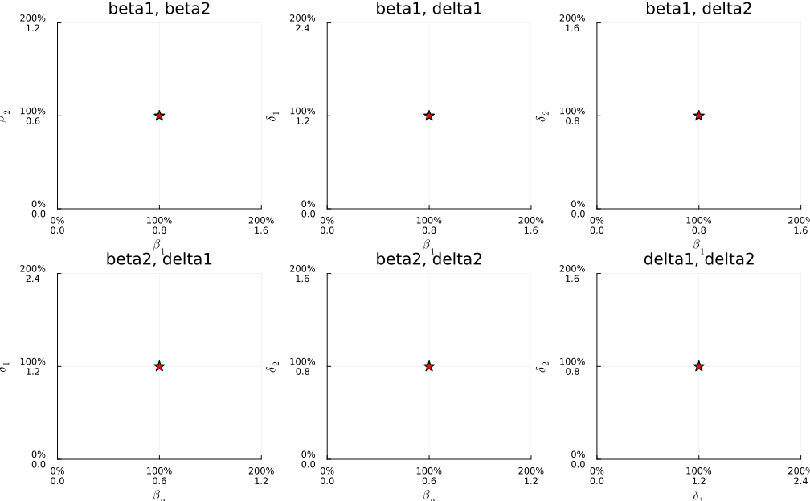

Figure 3: Pairwise projections of grid points with $Q^{\mathrm{pop}}(\theta)=0$.

```julia
exact_grid_projection_figures = [
    identified_projection_plot(
        identified = exact_grid_candidates,
        x_name = pair[1],
        y_name = pair[2],
        truth = settings.true_theta,
        labels = parameter_labels,
    )
    for pair in parameter_pairs
]

plot(
    exact_grid_projection_figures...;
    layout = (2, 3),
    size = (1_050, 650),
)
```

- The exact criterion and the $10^{-8}$ numerical check both retain only the true grid point.
- The grid-projection figure therefore contains one point in every projection.
- This result does not establish point identification: a Cartesian grid can miss a lower-dimensional set between its nodes.
- **Step 2: Trace the identified set between grid points**
  - Three independent equalities restrict four parameters, so one free dimension can remain.
  - Use $\beta_1$ as a continuation parameter.
  - For each value of $\beta_1$, re-solve $\beta_2$, $\delta_1$, and $\delta_2$.
  - $\beta_1$ indexes the curve; it is not the only unknown parameter.
- The no-entry equality gives $\beta_2$ directly as a function of $\beta_1$:

$$\Phi(-\beta_1)\Phi(-\beta_2)=p_{00}^0(1).$$

- Given $\beta_1$, solve

$$\beta_2(\beta_1)
=
-\Phi^{-1}\!\left(
\frac{p_{00}^0(1)}{\Phi(-\beta_1)}
\right).$$

- Then solve $(\delta_1,\delta_2)$ from the two all-entry probabilities:

$$p_{11}^0(0)
=\bar\Phi(\delta_2)\bar\Phi(\delta_1),$$

$$p_{11}^0(1)
=\bar\Phi(\delta_2-\beta_1)
\bar\Phi(\delta_1-\beta_2),$$

- Finally, retain solutions that satisfy the bounds for $(1,0)$ and $(0,1)$.

```julia
function bisect_root(function_value, lower, upper; iterations = 100)
    lower_value = function_value(lower)
    upper_value = function_value(upper)
    isfinite(lower_value) && isfinite(upper_value) || return nothing
    lower_value == 0 && return lower
    upper_value == 0 && return upper
    signbit(lower_value) == signbit(upper_value) && return nothing

    for _ in 1:iterations
        midpoint = (lower + upper) / 2
        midpoint_value = function_value(midpoint)
        midpoint_value == 0 && return midpoint
        if signbit(lower_value) == signbit(midpoint_value)
            lower = midpoint
            lower_value = midpoint_value
        else
            upper = midpoint
        end
    end
    return (lower + upper) / 2
end

function bracketed_roots(function_value, lower, upper; nodes = 1_001)
    grid = range(lower, upper; length = nodes)
    roots = Float64[]
    previous_x = first(grid)
    previous_value = function_value(previous_x)

    for current_x in Iterators.drop(grid, 1)
        current_value = function_value(current_x)
        if isfinite(previous_value) && isfinite(current_value)
            if previous_value == 0
                push!(roots, previous_x)
            elseif current_value == 0
                push!(roots, current_x)
            elseif signbit(previous_value) != signbit(current_value)
                root = bisect_root(
                    function_value,
                    previous_x,
                    current_x,
                )
                isnothing(root) || push!(roots, root)
            end
        end
        previous_x = current_x
        previous_value = current_value
    end
    return unique(round.(roots; digits = 12))
end
```

```julia
function trace_identified_candidates(;
    beta1_grid,
    truth,
    X_cells,
    observed_probabilities,
    cell_weights,
)
    standard_normal = Normal()
    p00_x1 = observed_probabilities[2, 1]
    p11_x0 = observed_probabilities[1, 4]
    p11_x1 = observed_probabilities[2, 4]
    rows = NamedTuple[]

    for beta1 in beta1_grid
        beta2_probability = p00_x1 / cdf(standard_normal, -beta1)
        0 < beta2_probability < 1 || continue
        beta2 = -quantile(standard_normal, beta2_probability)
        0 <= beta2 <= 2 * truth.beta2 || continue

        function delta2_from(delta1)
            delta2_tail = p11_x0 / ccdf(standard_normal, delta1)
            0 < delta2_tail < 1 || return NaN
            return quantile(standard_normal, 1 - delta2_tail)
        end

        delta1_roots = bracketed_roots(
            delta1 -> begin
                delta2 = delta2_from(delta1)
                isfinite(delta2) || return NaN
                return ccdf(standard_normal, delta2 - beta1) *
                    ccdf(standard_normal, delta1 - beta2) - p11_x1
            end,
            0.0,
            2 * truth.delta1,
        )

        for delta1 in delta1_roots
            delta2 = delta2_from(delta1)
            0 <= delta2 <= 2 * truth.delta2 || continue
            delta1 >= delta2 || continue
            bounds = analytic_equilibrium_bounds(
                X_cells = X_cells,
                beta1 = beta1,
                beta2 = beta2,
                delta1 = delta1,
                delta2 = delta2,
            )
            feasible =
                all(bounds.lower[:, 2:3] .<= observed_probabilities[:, 2:3]) &&
                all(observed_probabilities[:, 2:3] .<= bounds.upper[:, 2:3])
            feasible || continue
            objective = conditional_bound_violation_objective(
                observed_probabilities = observed_probabilities,
                cell_weights = cell_weights,
                bounds = bounds,
            )
            push!(
                rows,
                (
                    beta1 = beta1,
                    beta2 = beta2,
                    delta1 = delta1,
                    delta2 = delta2,
                    objective = objective,
                ),
            )
        end
    end
    return DataFrame(rows)
end

beta1_identification_grid = range(
    0.0,
    2 * settings.true_theta.beta1;
    length = 641,
)
traced_identified_candidates = trace_identified_candidates(
    beta1_grid = beta1_identification_grid,
    truth = settings.true_theta,
    X_cells = X_cells,
    observed_probabilities = population_probabilities,
    cell_weights = population_weights,
)

@assert maximum(traced_identified_candidates.objective) <= 1e-20
```

```julia
DataFrame(
    beta1_grid_points = [length(beta1_identification_grid)],
    retained_points = [nrow(traced_identified_candidates)],
    maximum_objective = [maximum(traced_identified_candidates.objective)],
)
```

1×3 DataFrame

| Row | beta1_grid_points Int64 | retained_points Int64 | maximum_objective Float64 |
| --- | --- | --- | --- |
| 1 | 641 | 68 | 1.60247e-28 |

- The code finds 68 feasible values along the $\beta_1$ grid, all with population loss below $10^{-20}$.
- The following figure projects the traced curve onto every pair of parameters.

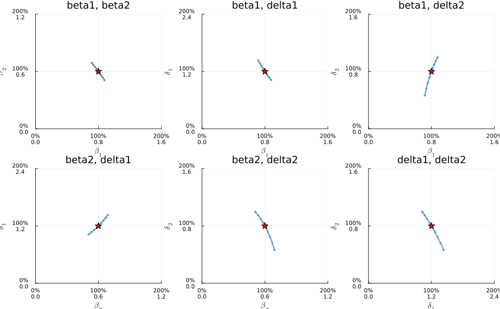

Figure 4: Pairwise projections of the population identified set traced by varying $\beta_1$.

```julia
traced_projection_figures = [
    identified_projection_plot(
        identified = traced_identified_candidates,
        x_name = pair[1],
        y_name = pair[2],
        truth = settings.true_theta,
        labels = parameter_labels,
        connect_in_beta1_order = true,
    )
    for pair in parameter_pairs
]

plot(
    traced_projection_figures...;
    layout = (2, 3),
    size = (1_050, 650),
)
```

- **Population result**
  - The four-dimensional grid retains only the true parameter vector.
  - The continuation exercise finds a curve of parameter vectors with $Q^{\mathrm{pop}}(\theta)=0$ up to numerical error.
  - The first result reflects the coarse grid; the second shows that the model is partially identified within the parameter box.

## 4. Generate data and check descriptive statistics

- Generate data from the DGP.
- Check descriptive statistics for the generated data.

### Remarks

- Check the variation in the outcomes.
  - A very rare outcome can weaken identification in a finite sample.

### Example: The Two-Firm Entry Model

- A market is the sampling unit.
- The DGP selects uniformly when both asymmetric equilibria are available.
- The estimator observes $(X_m,Y_{1m},Y_{2m})$.
- It does not observe the shocks, the selection draw, or the number of equilibria.

```julia
function simulate_markets(; rng, markets, theta, profiles)
    X = rand(rng, [0, 1], markets)
    epsilon = randn(rng, 2, markets)
    outcome = zeros(Int, markets)
    equilibrium_count = zeros(Int, markets)
    mask = falses(4)

    for market in 1:markets
        equilibrium_mask!(
            mask;
            X = X[market],
            epsilon = view(epsilon, :, market),
            beta1 = theta.beta1,
            beta2 = theta.beta2,
            delta1 = theta.delta1,
            delta2 = theta.delta2,
        )
        equilibria = findall(mask)
        isempty(equilibria) &&
            error("A generated market has no pure-strategy equilibrium.")
        outcome[market] = rand(rng, equilibria)
        equilibrium_count[market] = length(equilibria)
    end

    labels = ["(0,0)", "(1,0)", "(0,1)", "(1,1)"]
    return DataFrame(
        market = 1:markets,
        X = X,
        Y1 = profiles[1, outcome],
        Y2 = profiles[2, outcome],
        outcome = outcome,
        outcome_label = labels[outcome],
        equilibrium_count_dgp = equilibrium_count,
    )
end

example_data = simulate_markets(
    rng = MersenneTwister(settings.example_data_seed),
    markets = settings.sample_markets,
    theta = settings.true_theta,
    profiles = profiles,
)
```

5000×7 DataFrame

4975 rows omitted

| Row | market Int64 | X Int64 | Y1 Int64 | Y2 Int64 | outcome Int64 | outcome_label String | equilibrium_count_dgp Int64 |
| --- | --- | --- | --- | --- | --- | --- | --- |
| 1 | 1 | 1 | 0 | 1 | 3 | (0,1) | 1 |
| 2 | 2 | 0 | 1 | 0 | 2 | (1,0) | 1 |
| 3 | 3 | 1 | 1 | 0 | 2 | (1,0) | 1 |
| 4 | 4 | 0 | 1 | 0 | 2 | (1,0) | 1 |
| 5 | 5 | 1 | 1 | 0 | 2 | (1,0) | 1 |
| 6 | 6 | 1 | 1 | 0 | 2 | (1,0) | 1 |
| 7 | 7 | 1 | 1 | 0 | 2 | (1,0) | 2 |
| 8 | 8 | 0 | 1 | 0 | 2 | (1,0) | 1 |
| 9 | 9 | 0 | 1 | 0 | 2 | (1,0) | 1 |
| 10 | 10 | 1 | 1 | 0 | 2 | (1,0) | 1 |
| 11 | 11 | 1 | 1 | 0 | 2 | (1,0) | 2 |
| 12 | 12 | 1 | 1 | 0 | 2 | (1,0) | 1 |
| 13 | 13 | 0 | 0 | 0 | 1 | (0,0) | 1 |
| ⋮ | ⋮ | ⋮ | ⋮ | ⋮ | ⋮ | ⋮ | ⋮ |
| 4989 | 4989 | 1 | 0 | 1 | 3 | (0,1) | 1 |
| 4990 | 4990 | 1 | 0 | 1 | 3 | (0,1) | 1 |
| 4991 | 4991 | 1 | 1 | 0 | 2 | (1,0) | 2 |
| 4992 | 4992 | 1 | 0 | 1 | 3 | (0,1) | 1 |
| 4993 | 4993 | 1 | 1 | 0 | 2 | (1,0) | 1 |
| 4994 | 4994 | 1 | 0 | 1 | 3 | (0,1) | 2 |
| 4995 | 4995 | 0 | 0 | 1 | 3 | (0,1) | 1 |
| 4996 | 4996 | 0 | 0 | 1 | 3 | (0,1) | 1 |
| 4997 | 4997 | 1 | 0 | 1 | 3 | (0,1) | 2 |
| 4998 | 4998 | 0 | 0 | 0 | 1 | (0,0) | 1 |
| 4999 | 4999 | 1 | 1 | 0 | 2 | (1,0) | 1 |
| 5000 | 5000 | 0 | 0 | 1 | 3 | (0,1) | 1 |

```julia
first(
    select(example_data, :market, :X, :Y1, :Y2, :outcome_label),
    8,
)
```

8×5 DataFrame

| Row | market Int64 | X Int64 | Y1 Int64 | Y2 Int64 | outcome_label String |
| --- | --- | --- | --- | --- | --- |
| 1 | 1 | 1 | 0 | 1 | (0,1) |
| 2 | 2 | 0 | 1 | 0 | (1,0) |
| 3 | 3 | 1 | 1 | 0 | (1,0) |
| 4 | 4 | 0 | 1 | 0 | (1,0) |
| 5 | 5 | 1 | 1 | 0 | (1,0) |
| 6 | 6 | 1 | 1 | 0 | (1,0) |
| 7 | 7 | 1 | 1 | 0 | (1,0) |
| 8 | 8 | 0 | 1 | 0 | (1,0) |

- `outcome_label` reports the market structure directly.
- The integer `outcome` remains an internal array index.

```julia
DataFrame(
    markets = [nrow(example_data)],
    mean_X = [mean(example_data.X)],
    entry_rate_1 = [mean(example_data.Y1)],
    entry_rate_2 = [mean(example_data.Y2)],
    multiple_equilibrium_rate = [
        mean(example_data.equilibrium_count_dgp .> 1)
    ],
)
```

1×5 DataFrame

| Row | markets Int64 | mean_X Float64 | entry_rate_1 Float64 | entry_rate_2 Float64 | multiple_equilibrium_rate Float64 |
| --- | --- | --- | --- | --- | --- |
| 1 | 5000 | 0.5032 | 0.5394 | 0.3884 | 0.1192 |

```julia
combine(
    groupby(example_data, [:X, :outcome_label]),
    nrow => :markets,
)
```

8×3 DataFrame

| Row | X Int64 | outcome_label String | markets Int64 |
| --- | --- | --- | --- |
| 1 | 1 | (0,1) | 734 |
| 2 | 0 | (1,0) | 984 |
| 3 | 1 | (1,0) | 1293 |
| 4 | 0 | (0,0) | 630 |
| 5 | 0 | (0,1) | 788 |
| 6 | 1 | (1,1) | 338 |
| 7 | 0 | (1,1) | 82 |
| 8 | 1 | (0,0) | 151 |

- Every $X$ cell should contain all four market structures.
- `multiple_equilibrium_rate` is the fraction of simulated markets with two equilibria.
- It is a DGP audit, not an estimator input.

## 5. Estimate the model

- Define the objective function.
- Plot the objective function.
- Estimate the model.

### Remarks

- Check the shape of the objective function before estimation.
  - If the objective function does not have the expected shape, estimation will fail.
- When using an optimizer, do not place every initial value close to the true parameter vector.

### Example: The Two-Firm Entry Model

- Cell frequencies estimate

$$\widehat p_y(x)=\widehat{\Pr}(Y=y\mid X=x).$$

- The estimated set is

$$\widehat\Theta_I
=
\left\{
\theta\in\Theta:
nQ_n(\theta)\leq\log\log n
\right\}.$$

```julia
function empirical_moments(;
    data,
    X_cells,
    outcomes,
    rows = nothing,
)
    selected_rows = isnothing(rows) ?
        collect(axes(data, 1)) : collect(rows)
    observations = length(selected_rows)
    cells = length(X_cells)
    weights = zeros(cells)
    probabilities = zeros(cells, outcomes)

    for (cell, x) in enumerate(X_cells)
        cell_rows = filter(
            row -> data.X[row] == x,
            selected_rows,
        )
        isempty(cell_rows) && error("An X cell is empty.")
        weights[cell] = length(cell_rows) / observations
        for outcome in 1:outcomes
            probabilities[cell, outcome] = mean(
                data.outcome[cell_rows] .== outcome
            )
        end
    end
    return (probabilities = probabilities, weights = weights)
end

function sample_objective_curve(;
    data,
    X_cells,
    candidates,
    bounds_grid,
    rows = nothing,
)
    empirical = empirical_moments(
        data = data,
        X_cells = X_cells,
        outcomes = size(first(bounds_grid).lower, 2),
        rows = rows,
    )
    return conditional_objective_curve(
        candidates = candidates,
        observed_probabilities = empirical.probabilities,
        cell_weights = empirical.weights,
        bounds_grid = bounds_grid,
    )
end

example_curve = sample_objective_curve(
    data = example_data,
    X_cells = X_cells,
    candidates = candidates,
    bounds_grid = bounds_grid,
)
example_curve.scaled_objective =
    settings.sample_markets .* example_curve.objective
example_curve.estimated_set =
    example_curve.scaled_objective .<= log(log(settings.sample_markets))
```

[output not shown]

```julia
DataFrame(
    Q_n_at_truth = [example_curve.objective[true_index]],
    minimum_Q_n = [minimum(example_curve.objective)],
    estimated_grid_points = [count(example_curve.estimated_set)],
)
```

1×3 DataFrame

| Row | Q_n_at_truth Float64 | minimum_Q_n Float64 | estimated_grid_points Int64 |
| --- | --- | --- | --- |
| 1 | 4.92987e-5 | 2.03933e-5 | 494 |

```julia
projection_summary(
    candidates = candidates,
    retained = example_curve.estimated_set,
    truth = settings.true_theta,
)
```

4×4 DataFrame

| Row | parameter String | truth Float64 | lower Float64 | upper Float64 |
| --- | --- | --- | --- | --- |
| 1 | beta1 | 0.8 | 0.444444 | 1.15556 |
| 2 | beta2 | 0.6 | 0.2 | 1.06667 |
| 3 | delta1 | 1.2 | 0.933333 | 1.73333 |
| 4 | delta2 | 0.8 | 0.355556 | 1.15556 |

- The next panels project the four-dimensional estimated set onto every parameter pair.
- The shaded convex hull summarizes projected grid points; it is not the set itself.

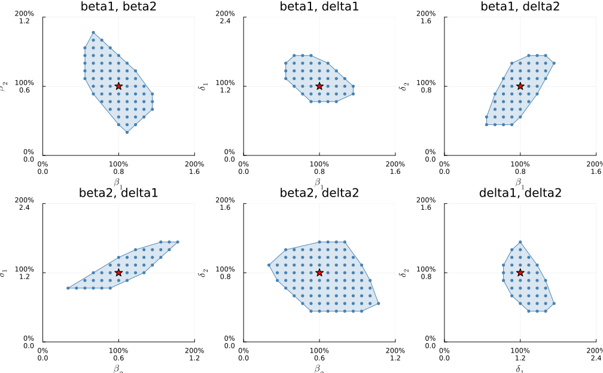

```julia
estimated_candidates = example_curve[example_curve.estimated_set, :]
estimated_projection_figures = [
    identified_projection_plot(
        identified = estimated_candidates,
        x_name = pair[1],
        y_name = pair[2],
        truth = settings.true_theta,
        labels = parameter_labels,
    )
    for pair in parameter_pairs
]

plot(
    estimated_projection_figures...;
    layout = (2, 3),
    size = (1_050, 650),
)
```

- The criterion retains 494 of 87,001 grid points in this sample.
- No one-dimensional projection reaches the 0- or 200-percent boundary.
- These projections are an estimated set, not a 95 percent confidence region.

## 6. Conduct inference

- Compute standard errors or a confidence region using an appropriate method.

### Remarks

- The appropriate method depends on the model.
- When resampling, first choose the resampling unit.
- For a regular point-identified model without an analytical asymptotic variance, a bootstrap may be sufficient.
- For a set-identified model, use a procedure designed to construct a confidence region for a parameter set.

### Example: The Two-Firm Entry Model

- Markets are independent sampling units.
- Subsampling draws markets without replacement.
- The subsample size is

$$b_n=\operatorname{round}(n^{0.8})=910.$$

- Each dataset uses 99 subsamples and two cutoff updates.
- The test statistic is

$$T_n(\theta)
=
n\left[
Q_n(\theta)-\min_{t\in\Theta}Q_n(t)
\right].$$

```julia
function draw_subsample(; rng, data, subsample_markets)
    return randperm(rng, nrow(data))[1:subsample_markets]
end

function subsampling_confidence_region(;
    data,
    X_cells,
    candidates,
    bounds_grid,
    confidence_level,
    subsample_markets,
    subsamples,
    iterations,
    rng,
)
    markets = nrow(data)
    full_curve = sample_objective_curve(
        data = data,
        X_cells = X_cells,
        candidates = candidates,
        bounds_grid = bounds_grid,
    )
    full_objective = full_curve.objective
    full_statistic = markets .* (
        full_objective .- minimum(full_objective)
    )
    subsample_statistics = zeros(subsamples, nrow(candidates))

    for draw in 1:subsamples
        rows = draw_subsample(
            rng = rng,
            data = data,
            subsample_markets = subsample_markets,
        )
        subsample_curve = sample_objective_curve(
            data = data,
            X_cells = X_cells,
            candidates = candidates,
            bounds_grid = bounds_grid,
            rows = rows,
        )
        subsample_objective = subsample_curve.objective
        subsample_statistics[draw, :] .= subsample_markets .* (
            subsample_objective .- minimum(subsample_objective)
        )
    end

    cutoff = 0.0
    critical_values = DataFrame(
        iteration = Int[],
        candidate_grid_points = Int[],
        critical_value = Float64[],
    )

    for iteration in 1:iterations
        candidate_indices = findall(
            full_statistic .<= cutoff + 1e-12
        )
        isempty(candidate_indices) &&
            error("The current confidence region is empty.")
        pointwise_cutoffs = [
            quantile(
                view(subsample_statistics, :, index),
                confidence_level,
            )
            for index in candidate_indices
        ]
        cutoff = maximum(pointwise_cutoffs)
        push!(
            critical_values,
            (iteration, length(candidate_indices), cutoff),
        )
    end

    curve = copy(candidates)
    curve.objective = full_objective
    curve.statistic = full_statistic
    curve.estimated_set =
        markets .* full_objective .<= log(log(markets))
    curve.confidence_set = full_statistic .<= cutoff

    return (
        curve = curve,
        critical_values = critical_values,
        final_critical_value = cutoff,
    )
end

example_inference = subsampling_confidence_region(
    data = example_data,
    X_cells = X_cells,
    candidates = candidates,
    bounds_grid = bounds_grid,
    confidence_level = settings.confidence_level,
    subsample_markets = settings.subsample_markets,
    subsamples = settings.subsamples,
    iterations = settings.inference_iterations,
    rng = MersenneTwister(settings.example_subsample_seed),
)
```

[output not shown]

```julia
example_inference.critical_values
```

2×3 DataFrame

| Row | iteration Int64 | candidate_grid_points Int64 | critical_value Float64 |
| --- | --- | --- | --- |
| 1 | 1 | 1 | 0.530164 |
| 2 | 2 | 101 | 1.90139 |

```julia
projection_summary(
    candidates = candidates,
    retained = example_inference.curve.confidence_set,
    truth = settings.true_theta,
)
```

4×4 DataFrame

| Row | parameter String | truth Float64 | lower Float64 | upper Float64 |
| --- | --- | --- | --- | --- |
| 1 | beta1 | 0.8 | 0.444444 | 1.15556 |
| 2 | beta2 | 0.6 | 0.2 | 1.06667 |
| 3 | delta1 | 1.2 | 0.933333 | 1.73333 |
| 4 | delta2 | 0.8 | 0.355556 | 1.15556 |

- The confidence region contains joint four-dimensional parameter vectors.
- Its panels show projections, not four separate confidence intervals.

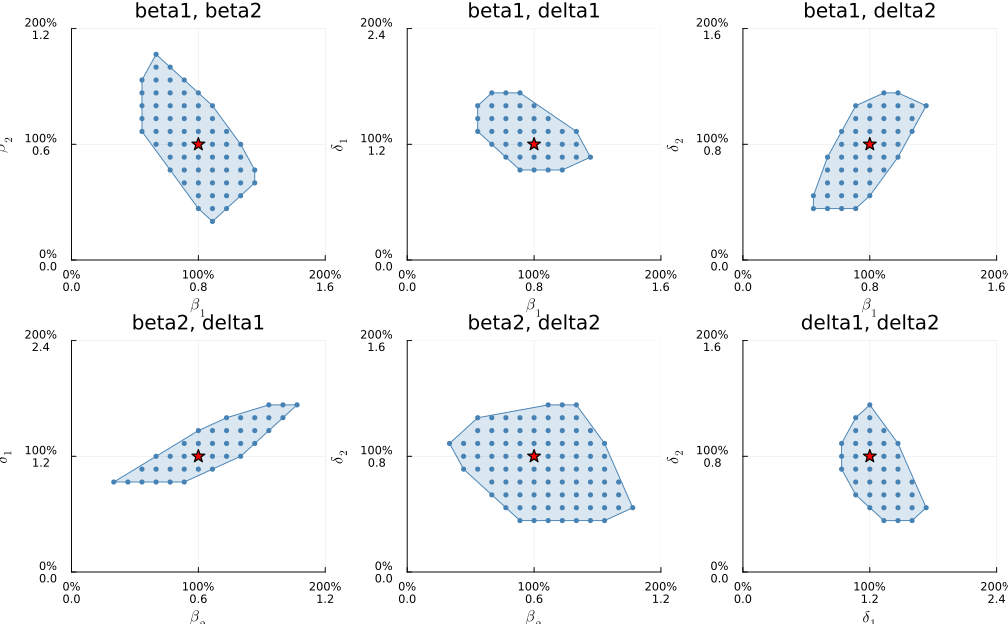

```julia
confidence_candidates = example_inference.curve[
    example_inference.curve.confidence_set,
    :,
]
confidence_projection_figures = [
    identified_projection_plot(
        identified = confidence_candidates,
        x_name = pair[1],
        y_name = pair[2],
        truth = settings.true_theta,
        labels = parameter_labels,
    )
    for pair in parameter_pairs
]

plot(
    confidence_projection_figures...;
    layout = (2, 3),
    size = (1_050, 650),
)
```

- The region collects candidate vectors that the sample cannot reject.
- It targets coverage of the true parameter in the identified set.
- The estimated set and confidence region use different cutoffs and need not be nested.

## 7. Run a counterfactual analysis

- Define the counterfactual scenario.
- Solve the model under the counterfactual scenario.
- Compare the counterfactual outcome with the baseline outcome.

### Remarks

- Because the true parameters are known, the true counterfactual effect is also known.
- Make an apples-to-apples comparison.
  - Compare the counterfactual model with the baseline model at the same parameter vector, not with the observed data.
- Choose an inference method for the counterfactual.
  - A regular point estimator may use the delta method or a parametric or nonparametric bootstrap.
  - A set estimator maps the joint parameter region into the counterfactual.
  - Do not combine endpoints from separate one-dimensional parameter intervals.

### Example: The Two-Firm Entry Model

- A subsidy adds $\tau=0.15$ only to firm 2’s entry profit:

$$\begin{aligned}
Y_{1m}
&=1\left[
X_m\beta_1-\delta_2Y_{2m}+\varepsilon_{1m}\geq0
\right],\\
Y_{2m}
&=1\left[
X_m\beta_2+\tau-\delta_1Y_{1m}+\varepsilon_{2m}\geq0
\right].
\end{aligned}$$

- We report two layers.
  - The known DGP uses uniform equilibrium selection and gives one probability change for each market structure.
  - The estimator leaves selection unspecified and reports changes in probability bounds.
- A change in a probability bound is not a bound on the policy effect.
  - A policy-effect bound requires an assumption linking selection before and after the policy.
- No entry is selection free because its lower and upper bounds coincide:

$$p_{00}(x;\theta,\tau)
=\Phi(-\beta_1x)\Phi(-\beta_2x-\tau).$$

```julia
function aggregate_outcome_probabilities(; probabilities, cell_weights)
    weighted = reshape(cell_weights, :, 1) .* probabilities
    return vec(sum(weighted; dims = 1))
end

function aggregate_outcome_bounds(; bounds, cell_weights)
    return (
        lower = aggregate_outcome_probabilities(
            probabilities = bounds.lower,
            cell_weights = cell_weights,
        ),
        upper = aggregate_outcome_probabilities(
            probabilities = bounds.upper,
            cell_weights = cell_weights,
        ),
    )
end

function no_entry_probability(; bounds, cell_weights)
    maximum(abs.(bounds.lower[:, 1] .- bounds.upper[:, 1])) <= 1e-12 ||
        error("No-entry probability is not point identified.")
    return sum(cell_weights .* bounds.lower[:, 1])
end

function counterfactual_curve(;
    candidates,
    baseline_bounds,
    policy_bounds,
    cell_weights,
)
    curve = copy(candidates)
    curve.baseline_no_entry = zeros(nrow(candidates))
    curve.policy_no_entry = zeros(nrow(candidates))
    curve.effect = zeros(nrow(candidates))

    for index in 1:nrow(candidates)
        baseline_probability = no_entry_probability(
            bounds = baseline_bounds[index],
            cell_weights = cell_weights,
        )
        policy_probability = no_entry_probability(
            bounds = policy_bounds[index],
            cell_weights = cell_weights,
        )
        curve.baseline_no_entry[index] = baseline_probability
        curve.policy_no_entry[index] = policy_probability
        curve.effect[index] = policy_probability - baseline_probability
    end
    return curve
end

function effect_range(; policy_curve, retained)
    any(retained) ||
        return (empty = true, lower = NaN, upper = NaN, width = NaN)
    effects = policy_curve.effect[retained]
    return (
        empty = false,
        lower = minimum(effects),
        upper = maximum(effects),
        width = maximum(effects) - minimum(effects),
    )
end

function bound_change_ranges(;
    baseline_bounds,
    policy_bounds,
    cell_weights,
    retained,
)
    indices = findall(retained)
    isempty(indices) && error("The retained set is empty.")
    rows = NamedTuple[]

    for outcome in 1:4
        for bound_name in (:lower, :upper)
            changes = [
                100 * sum(
                    cell_weights .* (
                        getproperty(policy_bounds[index], bound_name)[:, outcome] .-
                        getproperty(baseline_bounds[index], bound_name)[:, outcome]
                    )
                )
                for index in indices
            ]
            push!(
                rows,
                (
                    outcome = ["(0,0)", "(1,0)", "(0,1)", "(1,1)"][outcome],
                    probability_bound = String(bound_name),
                    lower_pp = minimum(changes),
                    upper_pp = maximum(changes),
                ),
            )
        end
    end
    return DataFrame(rows)
end

policy_bounds_grid = bounds_over_candidates(
    candidates = candidates,
    X_cells = X_cells,
    firm2_entry_subsidy = settings.firm2_entry_subsidy,
)
policy_curve = counterfactual_curve(
    candidates = candidates,
    baseline_bounds = bounds_grid,
    policy_bounds = policy_bounds_grid,
    cell_weights = population_weights,
)

true_policy_bounds = policy_bounds_grid[true_index]
true_policy_probabilities = uniform_selection_probabilities(
    bounds = true_policy_bounds,
)
baseline_dgp_probabilities = aggregate_outcome_probabilities(
    probabilities = population_probabilities,
    cell_weights = population_weights,
)
policy_dgp_probabilities = aggregate_outcome_probabilities(
    probabilities = true_policy_probabilities,
    cell_weights = population_weights,
)

dgp_market_structure_changes = DataFrame(
    market_structure = ["(0,0)", "(1,0)", "(0,1)", "(1,1)"],
    change_percentage_points = 100 .* (
        policy_dgp_probabilities .- baseline_dgp_probabilities
    ),
)

function entry_measures(probabilities)
    return [
        probabilities[2] + probabilities[4],
        probabilities[3] + probabilities[4],
        1 - probabilities[1],
    ]
end

entry_measure_changes = 100 .* (
    entry_measures(policy_dgp_probabilities) .-
    entry_measures(baseline_dgp_probabilities)
)
```

```
3-element Vector{Float64}:
 -1.3768625739358997
  5.011083875657957
  1.9949310845550516
```

- Under the DGP’s uniform rule, the subsidy raises firm 2’s entry probability and displaces some firm 1 entry.

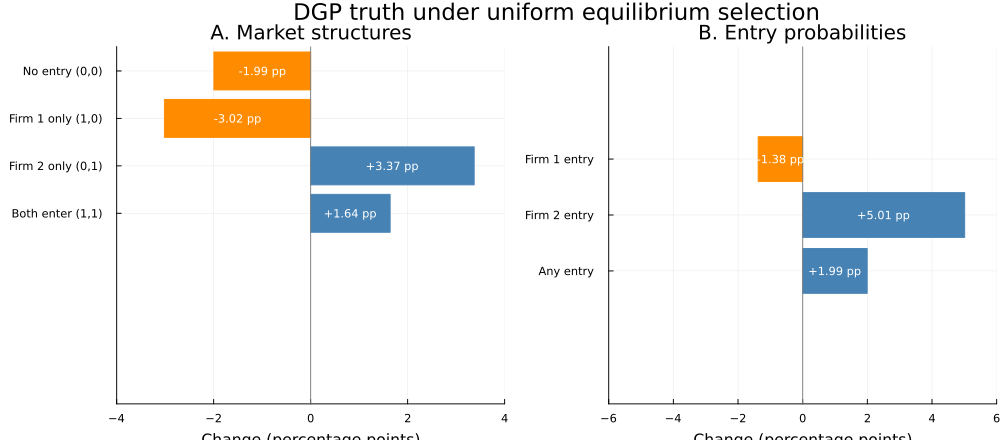

```julia
function signed_bar_panel(; labels, values, title, x_limits)
    display_values = reverse(values)
    display_labels = reverse(labels)
    colors = [value >= 0 ? :steelblue : :darkorange for value in display_values]
    figure = bar(
        display_values;
        orientation = :h,
        yticks = (1:length(display_labels), display_labels),
        color = colors,
        linecolor = colors,
        xlabel = "Change (percentage points)",
        title = title,
        xlims = x_limits,
        legend = false,
    )
    vline!(figure, [0.0]; color = :gray50, linewidth = 1)
    for (row, value) in enumerate(display_values)
        sign = value > 0 ? "+" : ""
        annotate!(
            figure,
            value / 2,
            row,
            text("$(sign)$(round(value; digits = 2)) pp", 8, :white),
        )
    end
    return figure
end

dgp_market_structure_plot = signed_bar_panel(
    labels = [
        "No entry (0,0)",
        "Firm 1 only (1,0)",
        "Firm 2 only (0,1)",
        "Both enter (1,1)",
    ],
    values = dgp_market_structure_changes.change_percentage_points,
    title = "A. Market structures",
    x_limits = (-4.0, 4.0),
)
dgp_entry_plot = signed_bar_panel(
    labels = ["Firm 1 entry", "Firm 2 entry", "Any entry"],
    values = entry_measure_changes,
    title = "B. Entry probabilities",
    x_limits = (-6.0, 6.0),
)

plot(
    dgp_market_structure_plot,
    dgp_entry_plot;
    layout = (1, 2),
    size = (1_050, 460),
    plot_title = "DGP truth under uniform equilibrium selection",
)
```

- Firm 2’s entry probability rises by about 5.01 percentage points.
- Firm 1’s entry probability falls by about 1.38 percentage points.
- The probability of any entry rises by about 1.99 percentage points.
- These statements use the DGP’s selection rule.

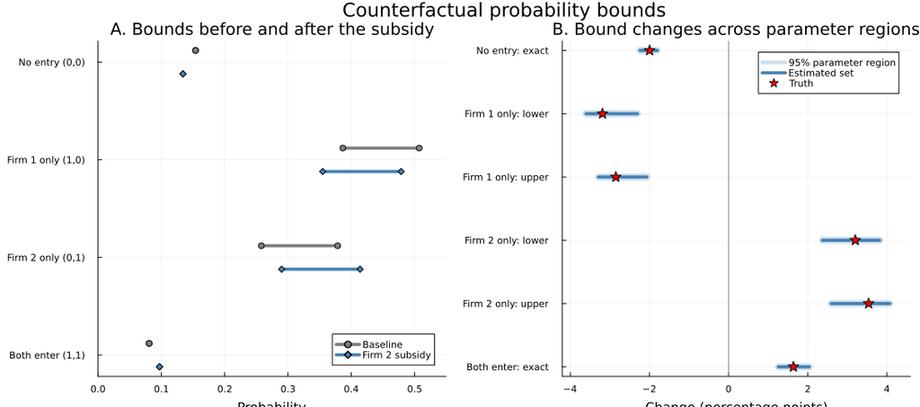

```julia
true_bound_changes = bound_change_ranges(
    baseline_bounds = bounds_grid,
    policy_bounds = policy_bounds_grid,
    cell_weights = population_weights,
    retained = eachindex(policy_bounds_grid) .== true_index,
)
rename!(
    true_bound_changes,
    :lower_pp => :truth_parameter_change_pp,
)
select!(
    true_bound_changes,
    :outcome,
    :probability_bound,
    :truth_parameter_change_pp,
)

estimated_bound_changes = bound_change_ranges(
    baseline_bounds = bounds_grid,
    policy_bounds = policy_bounds_grid,
    cell_weights = population_weights,
    retained = example_inference.curve.estimated_set,
)
rename!(
    estimated_bound_changes,
    :lower_pp => :estimated_lower_pp,
    :upper_pp => :estimated_upper_pp,
)

confidence_bound_changes = bound_change_ranges(
    baseline_bounds = bounds_grid,
    policy_bounds = policy_bounds_grid,
    cell_weights = population_weights,
    retained = example_inference.curve.confidence_set,
)
rename!(
    confidence_bound_changes,
    :lower_pp => :confidence_lower_pp,
    :upper_pp => :confidence_upper_pp,
)

bound_change_summary = innerjoin(
    true_bound_changes,
    estimated_bound_changes,
    confidence_bound_changes;
    on = [:outcome, :probability_bound],
)

baseline_aggregate_bounds = aggregate_outcome_bounds(
    bounds = population_bounds,
    cell_weights = population_weights,
)
policy_aggregate_bounds = aggregate_outcome_bounds(
    bounds = true_policy_bounds,
    cell_weights = population_weights,
)

outcome_labels = [
    "No entry (0,0)",
    "Firm 1 only (1,0)",
    "Firm 2 only (0,1)",
    "Both enter (1,1)",
]
probability_bound_plot = plot(
    xlabel = "Probability",
    title = "A. Bounds before and after the subsidy",
    xlims = (0.0, 0.55),
    yticks = (1:4, reverse(outcome_labels)),
    legend = :bottomright,
)

for (plot_row, outcome) in enumerate(reverse(1:4))
    baseline_y = plot_row + 0.12
    policy_y = plot_row - 0.12
    plot!(
        probability_bound_plot,
        [
            baseline_aggregate_bounds.lower[outcome],
            baseline_aggregate_bounds.upper[outcome],
        ],
        [baseline_y, baseline_y];
        color = :gray50,
        linewidth = 4,
        marker = :circle,
        markersize = 4,
        label = plot_row == 1 ? "Baseline" : "",
    )
    plot!(
        probability_bound_plot,
        [
            policy_aggregate_bounds.lower[outcome],
            policy_aggregate_bounds.upper[outcome],
        ],
        [policy_y, policy_y];
        color = :steelblue,
        linewidth = 4,
        marker = :diamond,
        markersize = 4,
        label = plot_row == 1 ? "Firm 2 subsidy" : "",
    )
end

bound_plot_keys = [
    ("(0,0)", "lower"),
    ("(1,0)", "lower"),
    ("(1,0)", "upper"),
    ("(0,1)", "lower"),
    ("(0,1)", "upper"),
    ("(1,1)", "lower"),
]
bound_plot_labels = [
    "No entry: exact",
    "Firm 1 only: lower",
    "Firm 1 only: upper",
    "Firm 2 only: lower",
    "Firm 2 only: upper",
    "Both enter: exact",
]
bound_plot_rows = [
    something(findfirst(
        (bound_change_summary.outcome .== outcome) .&
        (bound_change_summary.probability_bound .== probability_bound)
    ))
    for (outcome, probability_bound) in bound_plot_keys
]
bound_change_plot_data = bound_change_summary[bound_plot_rows, :]

bound_change_plot = plot(
    xlabel = "Change (percentage points)",
    title = "B. Bound changes across parameter regions",
    xlims = (-4.2, 4.6),
    yticks = (1:6, reverse(bound_plot_labels)),
    legend = :topright,
)
vline!(bound_change_plot, [0.0]; color = :gray50, linewidth = 1, label = "")

for (plot_row, index) in enumerate(reverse(1:nrow(bound_change_plot_data)))
    plot!(
        bound_change_plot,
        [
            bound_change_plot_data.confidence_lower_pp[index],
            bound_change_plot_data.confidence_upper_pp[index],
        ],
        [plot_row, plot_row];
        color = :steelblue,
        alpha = 0.25,
        linewidth = 9,
        label = plot_row == 1 ? "95% parameter region" : "",
    )
    plot!(
        bound_change_plot,
        [
            bound_change_plot_data.estimated_lower_pp[index],
            bound_change_plot_data.estimated_upper_pp[index],
        ],
        [plot_row, plot_row];
        color = :steelblue,
        linewidth = 4,
        label = plot_row == 1 ? "Estimated set" : "",
    )
    scatter!(
        bound_change_plot,
        [bound_change_plot_data.truth_parameter_change_pp[index]],
        [plot_row];
        color = :red,
        marker = :star5,
        markersize = 7,
        label = plot_row == 1 ? "Truth" : "",
    )
end

plot(
    probability_bound_plot,
    bound_change_plot;
    layout = (1, 2),
    size = (1_150, 510),
    plot_title = "Counterfactual probability bounds",
)
```

- Panel A compares the probability bounds before and after the subsidy.
- Panel B maps the estimated set and confidence region into changes in those bounds.
- The four-dimensional confidence region is

$$\widehat C_{\theta,G}
=
\left\{
\theta_g:T_n(\theta_g)\leq\widehat c_{1-\alpha}
\right\}.$$

- For a counterfactual $g(\theta)$, report

$$\left[
\min_{\theta_g\in\widehat C_{\theta,G}}g(\theta_g),
\quad
\max_{\theta_g\in\widehat C_{\theta,G}}g(\theta_g)
\right].$$

- This mapping preserves dependence among $\beta_1$, $\beta_2$, $\delta_1$, and $\delta_2$.
- It never recombines incompatible endpoints from marginal projections.

```julia
true_policy_effect = policy_curve.effect[true_index]
estimated_effect_range = effect_range(
    policy_curve = policy_curve,
    retained = example_inference.curve.estimated_set,
)
confidence_effect_range = effect_range(
    policy_curve = policy_curve,
    retained = example_inference.curve.confidence_set,
)

DataFrame(
    result = ["Truth", "Estimated set", "95% confidence region"],
    lower = [
        true_policy_effect,
        estimated_effect_range.lower,
        confidence_effect_range.lower,
    ],
    upper = [
        true_policy_effect,
        estimated_effect_range.upper,
        confidence_effect_range.upper,
    ],
)
```

3×3 DataFrame

| Row | result String | lower Float64 | upper Float64 |
| --- | --- | --- | --- |
| 1 | Truth | -0.0199493 | -0.0199493 |
| 2 | Estimated set | -0.0223636 | -0.0179843 |
| 3 | 95% confidence region | -0.0223636 | -0.0181045 |

- The no-entry effect is selection free and remains the formal coverage target.
- Richer market-structure changes depend on how equilibrium selection responds to the policy.

```julia
function monte_carlo_replication(;
    replication,
    settings,
    profiles,
    X_cells,
    candidates,
    bounds_grid,
    policy_curve,
    true_index,
    true_policy_effect,
)
    started_at = time_ns()
    try
        data = simulate_markets(
            rng = MersenneTwister(
                settings.monte_carlo_data_seed + replication
            ),
            markets = settings.sample_markets,
            theta = settings.true_theta,
            profiles = profiles,
        )
        inference = subsampling_confidence_region(
            data = data,
            X_cells = X_cells,
            candidates = candidates,
            bounds_grid = bounds_grid,
            confidence_level = settings.confidence_level,
            subsample_markets = settings.subsample_markets,
            subsamples = settings.subsamples,
            iterations = settings.inference_iterations,
            rng = MersenneTwister(
                settings.monte_carlo_subsample_seed + replication
            ),
        )
        estimated = inference.curve.estimated_set
        confidence = inference.curve.confidence_set
        policy_range = effect_range(
            policy_curve = policy_curve,
            retained = confidence,
        )
        policy_covered =
            !policy_range.empty &&
            policy_range.lower <= true_policy_effect <= policy_range.upper

        return (
            replication = replication,
            numerical_success = true,
            estimated_set_contains_truth = estimated[true_index],
            parameter_covered = confidence[true_index],
            counterfactual_covered = policy_covered,
            estimated_grid_points = count(estimated),
            confidence_grid_points = count(confidence),
            counterfactual_range_width = policy_range.width,
            multiplicity_rate = mean(data.equilibrium_count_dgp .> 1),
            critical_value = inference.final_critical_value,
            runtime_seconds = (time_ns() - started_at) / 1e9,
            failure_reason = "",
        )
    catch error
        return (
            replication = replication,
            numerical_success = false,
            estimated_set_contains_truth = false,
            parameter_covered = false,
            counterfactual_covered = false,
            estimated_grid_points = 0,
            confidence_grid_points = 0,
            counterfactual_range_width = NaN,
            multiplicity_rate = NaN,
            critical_value = NaN,
            runtime_seconds = (time_ns() - started_at) / 1e9,
            failure_reason = sprint(showerror, error),
        )
    end
end

function run_monte_carlo(;
    settings,
    profiles,
    X_cells,
    candidates,
    bounds_grid,
    policy_curve,
    true_index,
    true_policy_effect,
)
    rows = [
        monte_carlo_replication(
            replication = replication,
            settings = settings,
            profiles = profiles,
            X_cells = X_cells,
            candidates = candidates,
            bounds_grid = bounds_grid,
            policy_curve = policy_curve,
            true_index = true_index,
            true_policy_effect = true_policy_effect,
        )
        for replication in 1:settings.replications
    ]
    return DataFrame(rows)
end

function coverage_mcse(; coverage, replications)
    return sqrt(coverage * (1 - coverage) / replications)
end

function monte_carlo_summary(; results)
    successful = results[results.numerical_success, :]
    replications = nrow(successful)
    replications > 0 || error("All Monte Carlo replications failed.")
    parameter_coverage = mean(successful.parameter_covered)
    counterfactual_coverage = mean(successful.counterfactual_covered)

    return DataFrame(
        attempted_replications = [nrow(results)],
        numerical_successes = [replications],
        estimated_set_truth_inclusion = [
            mean(successful.estimated_set_contains_truth)
        ],
        parameter_coverage = [parameter_coverage],
        parameter_coverage_mcse = [
            coverage_mcse(
                coverage = parameter_coverage,
                replications = replications,
            )
        ],
        counterfactual_coverage = [counterfactual_coverage],
        counterfactual_coverage_mcse = [
            coverage_mcse(
                coverage = counterfactual_coverage,
                replications = replications,
            )
        ],
        mean_estimated_grid_points = [
            mean(successful.estimated_grid_points)
        ],
        mean_confidence_grid_points = [
            mean(successful.confidence_grid_points)
        ],
        mean_counterfactual_range_width = [
            mean(successful.counterfactual_range_width)
        ],
        mean_multiplicity_rate = [mean(successful.multiplicity_rate)],
        mean_runtime_seconds = [mean(successful.runtime_seconds)],
    )
end
```

```
monte_carlo_summary (generic function with 1 method)
```

- The outer loop generates a new dataset, re-estimates the set, reconstructs the confidence region, and maps it into the no-entry counterfactual.

```julia
monte_carlo_started_at = time_ns()
monte_carlo_results = run_monte_carlo(
    settings = settings,
    profiles = profiles,
    X_cells = X_cells,
    candidates = candidates,
    bounds_grid = bounds_grid,
    policy_curve = policy_curve,
    true_index = true_index,
    true_policy_effect = true_policy_effect,
)
monte_carlo_runtime_seconds =
    (time_ns() - monte_carlo_started_at) / 1e9

monte_carlo_table = monte_carlo_summary(results = monte_carlo_results)
monte_carlo_table.total_runtime_seconds .= monte_carlo_runtime_seconds
monte_carlo_table
```

1×13 DataFrame

| Row | attempted_replications Int64 | numerical_successes Int64 | estimated_set_truth_inclusion Float64 | parameter_coverage Float64 | parameter_coverage_mcse Float64 | counterfactual_coverage Float64 | counterfactual_coverage_mcse Float64 | mean_estimated_grid_points Float64 | mean_confidence_grid_points Float64 | mean_counterfactual_range_width Float64 | mean_multiplicity_rate Float64 | mean_runtime_seconds Float64 | total_runtime_seconds Float64 |
| --- | --- | --- | --- | --- | --- | --- | --- | --- | --- | --- | --- | --- | --- |
| 1 | 100 | 100 | 1.0 | 1.0 | 0.0 | 1.0 | 0.0 | 538.98 | 544.44 | 0.00424749 | 0.121376 | 0.338015 | 33.9512 |

```julia
failed_replications = monte_carlo_results[
    .!monte_carlo_results.numerical_success,
    :,
]

if nrow(failed_replications) == 0
    DataFrame(failure_reason = String[], replications = Int[])
else
    combine(
        groupby(failed_replications, :failure_reason),
        nrow => :replications,
    )
end
```

0×2 DataFrame

| Row | failure_reason | replications |
| --- | --- | --- |
|  | String | Int64 |

- Report numerical success, truth inclusion, coverage with Monte Carlo standard errors, set size, multiplicity, and runtime.
- In this 100-replication run:
  - all replications complete numerically;
  - the mean estimated set contains about 539 of 87,001 grid points;
  - the mean confidence region contains about 544 grid points;
  - parameter and counterfactual coverage both equal 1.00;
  - recent renders take roughly 30–40 seconds on the reference machine.
- One hundred replications are too few for a precise assessment of tail coverage.
- A production study should increase both replications and grid resolution.

## References

- Ciliberto, Federico, and Elie Tamer. 2009. “Market Structure and Multiple Equilibria in Airline Markets.” *Econometrica* 77 (6): 1791–1828. https://doi.org/10.3982/ECTA5368.
- Chernozhukov, Victor, Han Hong, and Elie Tamer. 2007. “Estimation and Confidence Regions for Parameter Sets in Econometric Models.” *Econometrica* 75 (5): 1243–1284.